# Forschungsbericht_SNA_TheVoice | Modul: Soziale Netzwerke 226305

## Visualisierung Gesamtnetzwerk

[figure not shown]

```r
# ChatGPT 1: Die von ChatGPT generierten Zeilen innerhalb dieses Codes wurden markiert.
# In diesem Bericht werden diese Codezeilen in mehreren Berechnungen verwendet.
# Im Anhang sind unter dem Punkt "ChatGPT" sowohl der Promt als auch das Ergebnis
# von ChatGPT aufgeführt.

# Die nachfolgenden Codezeilen wurden von ChatGPT generiert
# Funktion, um Farben basierend auf 'role' zuzuweisen
assign_colors_to_roles <- function(role) {
  ifelse(role == 1, "blue",
    ifelse(role == 2, "red",
      ifelse(role == 3, "green",
        ifelse(role == 4, "yellow",
          ifelse(role == 5, "purple", "orange")))))
}

# Die nachfolgenden Codezeilen wurden von ChatGPT generiert
# Funktion, um Farben basierend auf 'Relation' zuzuweisen
# Hier wird eine neue Farbzuordnung angenommen
assign_colors_to_relations <- function(relation) {
  ifelse(relation == 1, "cyan",
    ifelse(relation == 2, "magenta",
      ifelse(relation == 3, "black",
        ifelse(relation == 4, "grey",
          ifelse(relation == 5, "gold", "brown")))))

}

# Visualisierung
# Die Verwendung von 'vertex.color' und 'edge.color' muss entsprechend angepasst werden
plot(tv, layout=layout_with_kk(tv),
     vertex.size=V(tv)$Spotify/1000000,
     vertex.label.cex=0.6,
     vertex.label.color="black",
     vertex.shape = ifelse(V(tv)$type == "1", "circle", "square"),
     vertex.label.dist=1,
     vertex.label.family="sans",
     edge.curved=0.1,
     # Anpassung basierend auf 'role' , von ChatGPT generiert
     vertex.color=sapply(V(tv)$role, assign_colors_to_roles),
     # Anpassung basierend auf 'Relation', von ChatGPT generiert
     edge.color=sapply(E(tv)$relation, assign_colors_to_relations),
     edge.width=0.5,
     edge.label=E(tv)$year,
     main="Connections der The Voice of Germany FinalistInnen",
     sub="Welche Verbindungen bestehen zwischen den FinalistInnen und anderen   KünstlerInnen,
     ProduzentInnen, SongwriterInnen, Labels und/oder anderen Shows?")
```

## Zentralitätsmaße Gesamtnetzwerk

Betrachtet man die Zentralitätsmaße des Gesamtnetzwerks fällt auf, das insbesondere ein Finalist, Michael Schulte, eine sehr bedeutende Rolle im Netzwerk spielt. Durch seinen hohen Degree-Wert wird deutlich, dass er viele direkte Verbindungen innerhalb des Netzwerks hat (Mutschke, 2023, S. 4). Die hohe Betweenness-Zentralität zeigt, dass er auf vielen der kürzesten Wege zwischen anderen Knotenpaaren im Netzwerk liegt und somit eine wichtige Brückenfunktion erfüllt (Fuhse, 2018, S.60). Die hohe Closeness-Zentralität von Michael Schulte verdeutlicht, dass er eine zentrale Position im Netzwerk einnimmt und sehr nah zu den anderen Knoten liegt, wodurch er als eine Art Verteilerknoten angesehen werden kann (Rürup et al., 2015, S. 30).

```r
# Identifikation des Knotes mit höchstem Grad
which.max(degree(tv, mode = "all")) # Michael Schulte
```

```
Michael Schulte
              1
```

```r
# Gesamtzahl der Verbindungen für Michael Schulte
degree(tv, mode = "all")[["Michael Schulte"]] # Michael Schulte hat 46 In-/Outdegrees
```

```
[1] 46
```

```r
# Betweenness-Zentralität für alle Knoten

betweenness_values <- betweenness(tv, normalized = TRUE)

# Erstellung einer Tabelle aus den Betweenness Werten
betweenness_df <- data.frame(Betweenness = betweenness_values)

# Ausgabe der obersten 5 Werte
head(betweenness_df, 5)
```

|  | Betweenness |
| --- | --- |
| Michael Schulte | 0.265023864 |
| Max Giesinger | 0.130081296 |
| Michael Lane | 0.020583535 |
| Andreas Kümmert | 0.050535380 |
| Freschta Akbarzada | 0.007639827 |

```r
# Knoten mit der höchsten Betweenness-Zentralität
max_between <- which.max(betweenness(tv))

# Betweenness-Wert für den führenden Knoten
betweenness(tv, normalized = TRUE)[max_between] # Michael Schulte: 0,265
```

```
Michael Schulte
      0.2650239
```

```r
# Knoten mit der geringsten Betweenness-Zentralität
min_betweenness <- which.min(betweenness(tv))

# Betweenness-Wert des niedrigsten Knotens
betweenness(tv, normalized = TRUE)[min_betweenness] # R3hab: 0
```

```
R3hab
    0
```

```r
# Closeness-Zentralität für alle Knoten

closeness_values <- closeness(tv, normalized = TRUE)

closeness_df <- data.frame(Closeness = closeness_values)

head(closeness_df, 5)
```

|  | Closeness |
| --- | --- |
| Michael Schulte | 0.3425926 |
| Max Giesinger | 0.3032787 |
| Michael Lane | 0.2371795 |
| Andreas Kümmert | 0.2619469 |
| Freschta Akbarzada | 0.2424242 |

```r
# Knoten mit der höchsten Closeness-Zentralität
max_closeness <- which.max(closeness(tv))

# Closeness-Wert des führenden Knotens
closeness(tv, normalized = TRUE)[max_closeness] # Michael Schulte: 0,343
```

```
Michael Schulte
      0.3425926
```

```r
# Knoten mit der geringsten Closeness-Zentralität
min_closeness <- which.min(closeness(tv))

# Closeness-Wert des niedrigsten Knotens
closeness(tv, normalized = TRUE)[min_closeness] # Noah Slee: 0.120
```

```
Noah Slee
0.1199352
```

## Egonetzwerk von Michael Schulte

```r
list.vertex.attributes(tv)
```

```
 [1] "name"          "type"          "role"          "sex"           "Showkategorie" "Charts"        "Platz"
 [8] "Spotify"       "Instagram"     "Staffel"
```

```r
tv_names <- vertex.attributes(tv)$name
tv_names[1:5]
```

```
[1] "Michael Schulte"    "Max Giesinger"      "Michael Lane "      "Andreas Kümmert"    "Freschta Akbarzada"
```

```r
# Ego-Netzwerk Michael Schulte
schulte <- make_ego_graph(tv, order=1, nodes=V(tv)$name == "Michael Schulte", mode = "all") # Einebziehung der Beziehungen ersten Grades

schulte
```

```
[[1]]
IGRAPH 56ec803 UN-B 41 63 --
+ attr: name (v/c), type (v/n), role (v/n), sex (v/n), Showkategorie (v/n), Charts (v/n), Platz (v/n), Spotify
| (v/n), Instagram (v/n), Staffel (v/n), relation (e/c), year (e/c)
+ edges from 56ec803 (vertex names):
 [1] Michael Schulte--Max Giesinger      Michael Schulte--Ivy Quainoo        Max Giesinger  --Ivy Quainoo
 [4] Michael Schulte--Kim Sanders        Max Giesinger  --Kim Sanders        Ivy Quainoo    --Kim Sanders
 [7] Michael Schulte--Alessandro Pola    Michael Schulte--Staffel 1          Max Giesinger  --Staffel 1
[10] Ivy Quainoo    --Staffel 1          Kim Sanders    --Staffel 1          Michael Schulte--Staffel 10
[13] Michael Schulte--Staffel 10         Alessandro Pola--Staffel 10         Michael Schulte--R3hab
[16] Michael Schulte--Norma Jean Martine Michael Schulte--YouNotUS           Michael Schulte--YouNotUS
[19] Michael Schulte--YouNotUS           Michael Schulte--Montez             Michael Schulte--Noel Gallagher
+ ... omitted several edges
```

```r
schulte_ego <- schulte[[1]]
schulte_ego
```

```
IGRAPH 56ec803 UN-B 41 63 --
+ attr: name (v/c), type (v/n), role (v/n), sex (v/n), Showkategorie (v/n), Charts (v/n), Platz (v/n), Spotify
| (v/n), Instagram (v/n), Staffel (v/n), relation (e/c), year (e/c)
+ edges from 56ec803 (vertex names):
 [1] Michael Schulte--Max Giesinger      Michael Schulte--Ivy Quainoo        Max Giesinger  --Ivy Quainoo
 [4] Michael Schulte--Kim Sanders        Max Giesinger  --Kim Sanders        Ivy Quainoo    --Kim Sanders
 [7] Michael Schulte--Alessandro Pola    Michael Schulte--Staffel 1          Max Giesinger  --Staffel 1
[10] Ivy Quainoo    --Staffel 1          Kim Sanders    --Staffel 1          Michael Schulte--Staffel 10
[13] Michael Schulte--Staffel 10         Alessandro Pola--Staffel 10         Michael Schulte--R3hab
[16] Michael Schulte--Norma Jean Martine Michael Schulte--YouNotUS           Michael Schulte--YouNotUS
[19] Michael Schulte--YouNotUS           Michael Schulte--Montez             Michael Schulte--Noel Gallagher
+ ... omitted several edges
```

```r
vcount(schulte_ego) # Das Netzwerk umfasst 41 Knoten
```

```
[1] 41
```

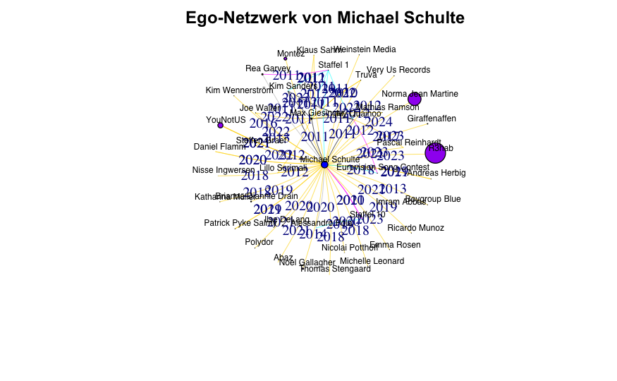

```r
# Funktion, um Farben basierend auf 'role' zuzuweisen
assign_colors_to_roles <- function(role) {
  ifelse(role == 1, "blue",
    ifelse(role == 2, "red",
      ifelse(role == 3, "green",
        ifelse(role == 4, "yellow",
          ifelse(role == 5, "purple", "orange")))))
}

# Funktion, um Farben basierend auf 'Relation' zuzuweisen
# Hier wird eine neue Farbzuordnung angenommen
assign_colors_to_relations <- function(relation) {
  ifelse(relation == 1, "cyan",
    ifelse(relation == 2, "magenta",
      ifelse(relation == 3, "black",
        ifelse(relation == 4, "grey",
          ifelse(relation == 5, "gold", "brown")))))
}


# Anwenden der Funktion auf jede 'role' und Speichern der Farben
V(schulte_ego)$color <- sapply(V(schulte_ego)$role, assign_colors_to_roles)


# Visualisierung
plot(schulte_ego, layout=layout_with_kk(schulte_ego),
     vertex.size=V(schulte_ego)$Spotify/1000000,
     vertex.label.cex=0.6,
     vertex.label.color="black",
     vertex.shape = ifelse(V(schulte_ego)$type == "1", "circle", "square"),
     vertex.label.dist=1,
     vertex.label.family="sans",
     edge.curved=0.1,
     vertex.color=sapply(V(schulte_ego)$role, assign_colors_to_roles), # Anpassung basierend auf 'role'
     edge.color=sapply(E(schulte_ego)$relation, assign_colors_to_relations), # Anpassung basierend auf 'Relation'
     edge.width=0.5,
     edge.label=E(schulte_ego)$year,
     main="Ego-Netzwerk von Michael Schulte"
    )
```